# Seattle Public Library Analysis

2023-02-25

## Introduction and Summary

I chose to work with the Seattle Public Library Data set of items checked out at least ten times a month from 2017 to 2023. This data set was extremely appealing because it covers a large amount of time while simultaneously showing the items that were the most popular. This data set did pose the risk of not having enough data to look at one item consistently over a year; it might have been checked out more than ten times several months out of the year, but checkouts fluctuate and could result in holes in the data. I was really interested in how TikTok and social media affected the popularity of particular books, and I was also interested in the transition to rented EBOOKs and Media types.

A paragraph of summary information, citing at least 5 values calculated from the data Because of my interest in the affect of COVID on media types, I chose to look at: Print books over six years, EBOOK over six years, Print and EBOOK what month had the highest and number of checkouts, what the total number of checkouts is for each material type, and the top ten media types over six years. The year with the highest number of EBOOK checkouts was 2020 with 1,080,133 checkouts. I believe 2020 had the most checkouts because of the COVID-19 quarantine. The year with the least number of EBOOK checkouts was 2023, with 99,883, however, due to the fact that were are only three months into 2023, this value cannot be considered an accurate representation of the EBOOK checkout data. The year with the lowest number of EBOOK checkouts is 2017 with 440,127 checkouts. 2018 had 1,527,112 print book checkouts, which is the highest number of checkouts in one year from 2017 to 2023. In 2020, there was the least number of print book checkouts from 2017 to 2022 with only 363,157 checkouts. When looking at the the total number of checkouts for each material type, the top five most checked out material types are: BOOK (6397967), EBOOK (5053218), AUDIOBOOK (3728672), VIDEODISC (3326554).

An introduction of the data and a description of the trends/books/items you are choosing to analyze (and why!) My friends and I participated in a TikTok Book club last year, and the first series we read together was the A Court of Thorns and Roses Franchise. This coupled with my love of classic romance novels inspired my analysis for this dataset. There are five books in the A Court of Thorns and Roses (ACOTAR) series: A Court of Thorns and Roses, A Court of Mist and Fury, A Court of Wings and Ruin, A Court of Frost and Starlight, and A Court of Silver and Flames. These books were originally released in 2015 by Sarah J. Maas. They became internationally known as one of the best Fantasy Romance novels of the 21st century. Upon release they were extremely famous, their popularity died down after the third book in 2017, which is approximately when the graph begins. After Tiktok became a platform for book lovers alike, ACOTAR once again rose to extreme fame. I was really interested to see the effect of social media on the series as a whole. As a romance genre lover and a bibliophile, I was really interested in looking at the rise of ebooks and the decline of print books in the Seattle Public Library’s checkout data. I am personally a fan of print books, and I am sad to see them becoming so expensive, but EBOOKs are much cheaper and better for the environment. Lastly, my all-time favorite author is Jane Austen, and my all-time favorite book is Pride and Prejudice, for my last graph I chose the analyze Jane Austens novels over time and which one is most popular overall.

## Data

> Who collected/published the data? - The Seattle Public Library Collected and published the data

> What are the parameters of the data (dates, number of checkouts, kinds of books, etc.)? - Checkout month, Checkout year, number of checkouts, Title, Author, Media (Material) type, Checkout type, Usage class, subjects, publisher are the parameters of the data set.

> How was the data collected or generated? - The data was collected with the logs of checkouts in the Seattle Public Library. ISBNs and other barcode identifyers help to keep track of the number of times items are rented.

> Why was the data collected? - This data was created to keep logs of the different components to checkouts: Authors, Publishers, Month, Year, Media class, Material typ, and popularity. This can help determine whether the library needs more copies of a particular item, or if they should move forward with more books by a particular author. This dataset could also potentially help them track lost items or pirating.

> What, if any, ethical questions do you need to consider when working with this data? - I believe there could be ethical questions regarding the applications and purposed of the data set. Should the seattle public library use the data set to change the Material Type or the availability of a particular item, it could have an impact on communities that do not have access to that particular Material type. For example, if most of the checkouts for a particular textbook was online, so they transition from print books to EBOOKS, some communities might be unable to access that book. I think there could also be ethical questions regarding the racial and gender distribution of the authors and creators of the books they purchase for the library, although, this issue is also a reflection of the publishing industry (in my opinion this issue would also pertain to the diversity of topics for books, movies, music and more).

> What are possible limitations or problems with this data? (at least 200 words) - This data, although updated monthly, has very large gaps due to the fluctuation in checkouts; not every item is going to be checked out 10 times each month. This allows for a lot of gaps in graphs or data analysis. Another very prominent issue is the multiple different titles that can exist for one item; special editions, capital letters, variations, and more all make it very difficult to find all of the data for one particular item. In order to work around this, I focused on making all of the titles completely lowercase, and then I used string detect to search for key phrases in the titles; for example, A Court of Thorns of Roses had several hundred variations, I applied tolower() to the titles, and then str_detect(“a court of thorns and roses”) to make sure I captured all variations. Once I had filtered all of the titles for certain phrases, I assigned them all to one specific name. This is a very time consuming process if someone had to do this for several hundred or thousands of books. Fortunately, I only had to correct 10 books, but I am sure this data set is used on a much larger scale, and this limitation would be very frustrating to correct. Finally, one small limitation is that 2023 is included in the dataset despite the fact that the year isn’t complete, when calculating yearly averages or analyzing data, 2023 has to be excluded.

## First Trend over time

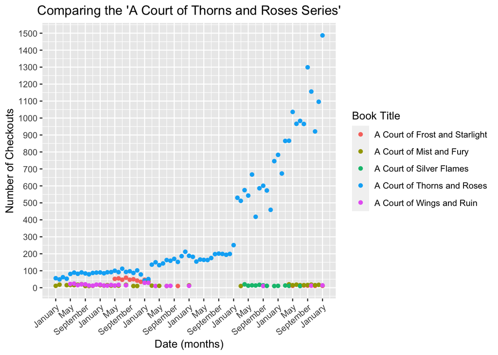

For this chart, I chose to use a scatter plot because many of the lines over lapped and looked muddled; another prominent issue was the lack of checkouts around 2020, which made the graph look like it was incomplete. I felt that with points, the lack of checkouts in 2020 looked much more natural.

## Second Trends over time

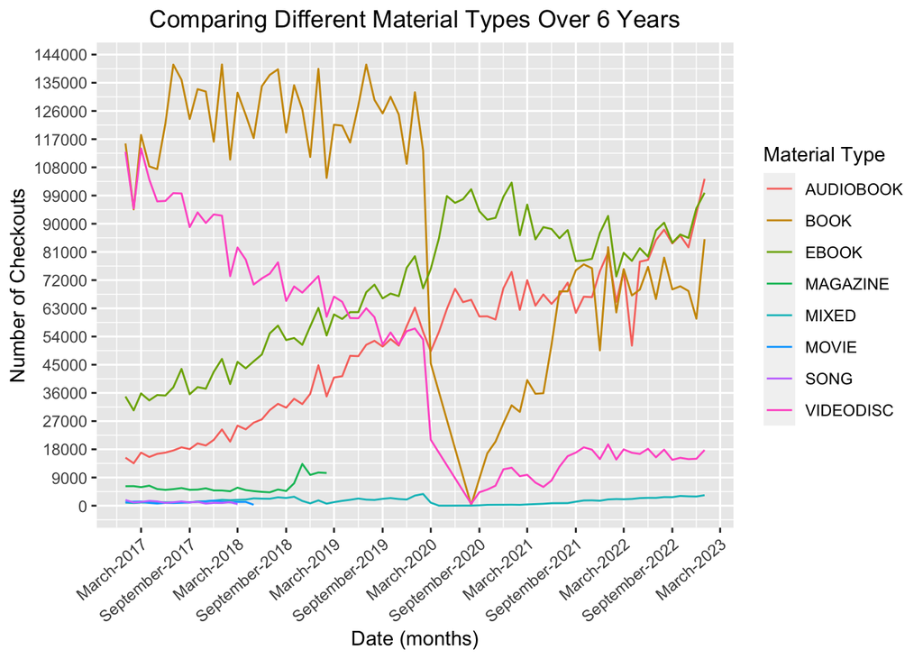

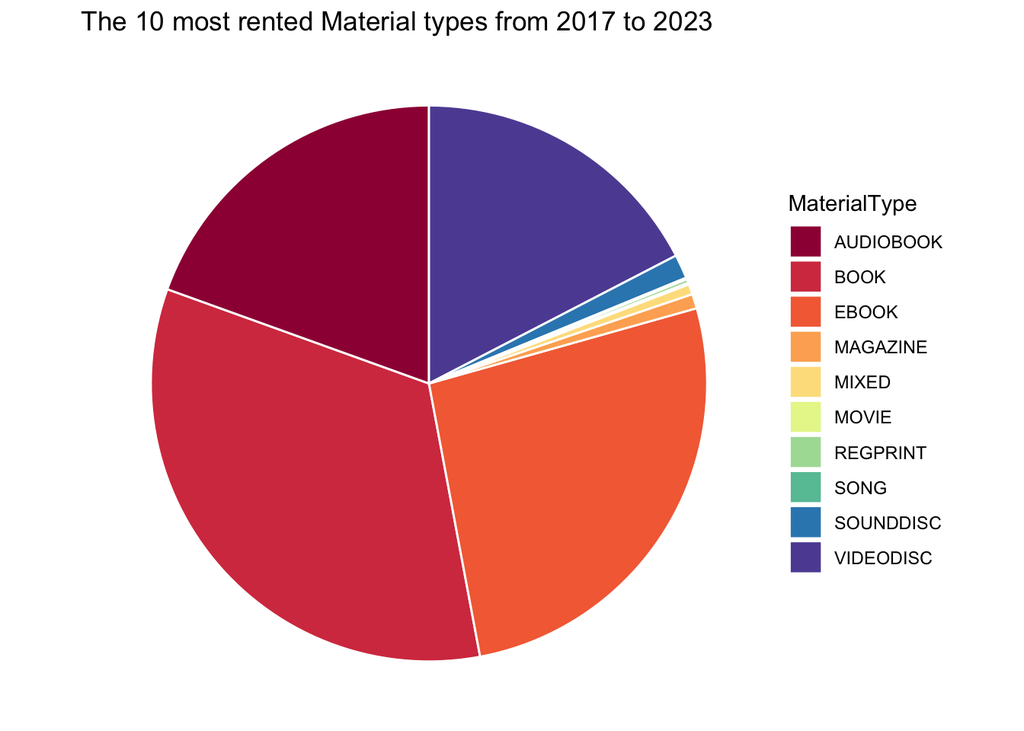

I decided to look at this trend in order to view the overall popularity and evolution of Material Types. I think it would have been really interesting to also look at the more long-term downfall of rented CDs, with the invention of Netflix. However, for this assignment, I was particularly interested in the relationship between EBOOKs and print books. For this chart, I had planned to choose the top ten most checked out media types, but ultimately, the two lowest materials had disappeared from the graph halfway through; this meant that the materials had 10 or fewer checkouts per month. I chose to do a line chart because it most clearly conveyed the popularity of material types over time. The question I hoped to answer with this chart was “Does the overwhelming increase in EBOOK popularity affect the number of checkouts for other material types?” I had considered other charts when deciding how to best demonstrate the relationship, the other option I felt could have worked well was a scatter plot, however because the focus of my question was the correlation between two variables, I ultimately decided to represent the data with a linear graph.

The chart shows that although the number of print book checkouts fluctuation on a monthly bases, the overall number of checkouts was very consistently around 126,000 checkouts per month until 2020, when the COVID 19 quarantine took place. The graph shows that the overall number of checkouts for EBOOKs and audiobooks was steadily increasing, starting out lower than 40,000 and reaching 100,000 at its peak. The quarantine made people transition to online versions of items in the library, even after quarantine ended, print books are not reaching the numbers they used to be, at most 90,000. This shows that the overall relationship of material items is a transition to online items.

## Your Choice Plot

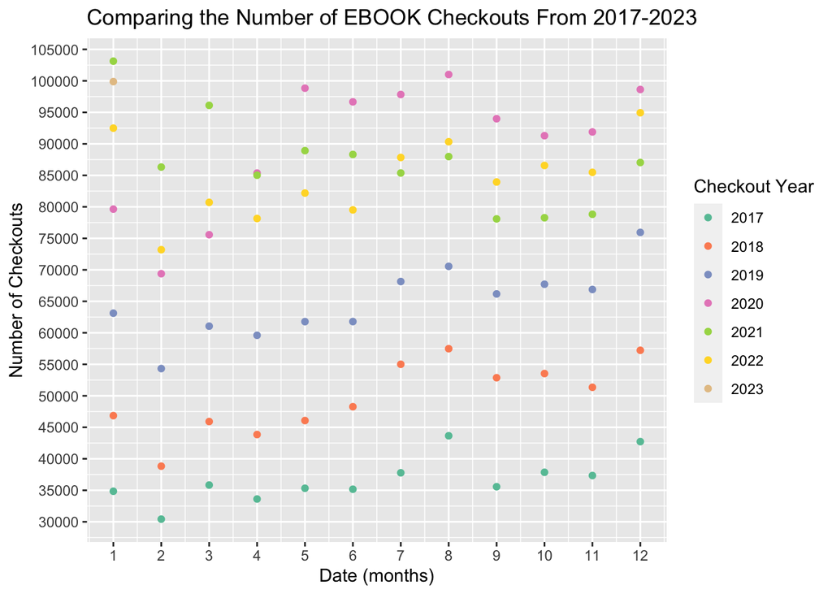

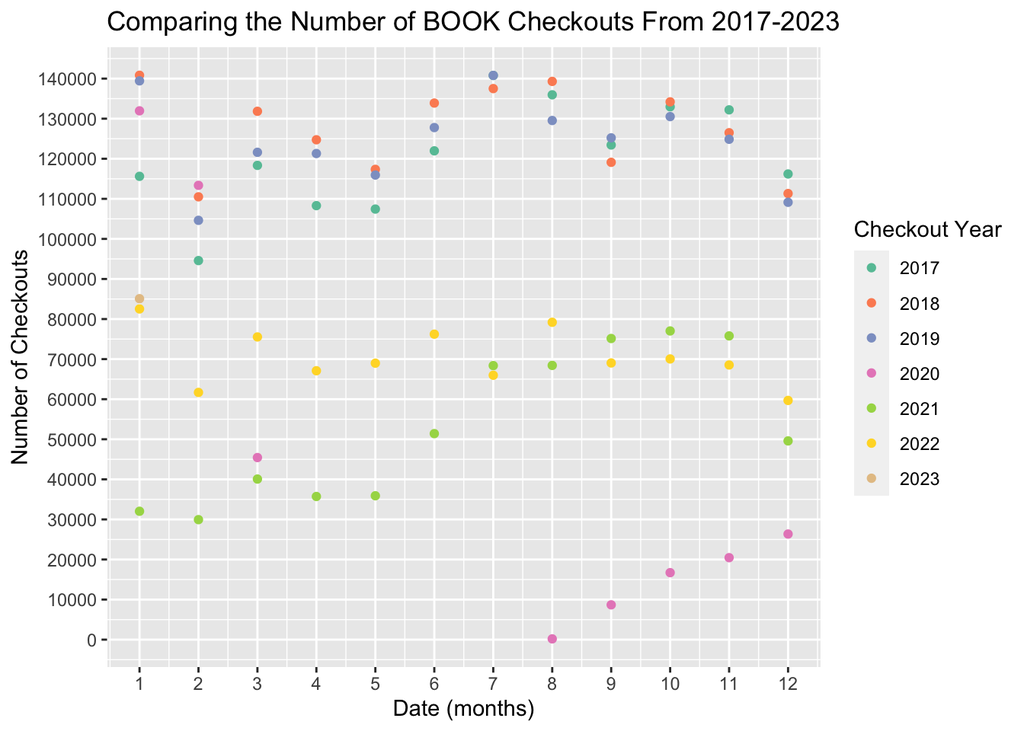

For my last chart, I chose to look more in depthly at the relationship between print books and EBOOKs, examining them over the time span of one year and comparing the years from 2017 to 2023. Each chart focuses on the specific material types individually, I felt this would best show the material types relationship to time as opposed to the other material types. For these graphs, I felt that because there was more space overall, the data would be best represented by points. I also noticed that when I tried to use lines for the graph, it felt very crowded, and it was more difficult to analyze the correlation between the material type and time.

When looking at the EBOOK graph, their peak for checkouts was 2020 due to the quarantine, however the two full years following the quarantine have been within about 20,000 checkouts per month from their highest year which was extremely varied, but most commonly about 90,000 checkouts per month. Although, EBOOK checkouts have not continued to increase, they have remained very stable for the past three years, suggesting that this might be the more consistent material that is checked out. Keeping in mind that e-reader platforms have become much more developed and common, in my opinion, EBOOKs are now the material type of choice. In comparison, print books had much higher numbers prior to the quarantine, reaching around 125,000 checkouts per month. Post quarantine the number of checkouts have dropped to about 70,000 checkouts per month. Most noticeably, it seems as though the average number of checkouts in total (for all material types) has dropped drastically, perhaps people do not go to the library as much.